# Optimizing Whiff Probability for Pitcher X

### Worst Whiff Probabilities Vs Left

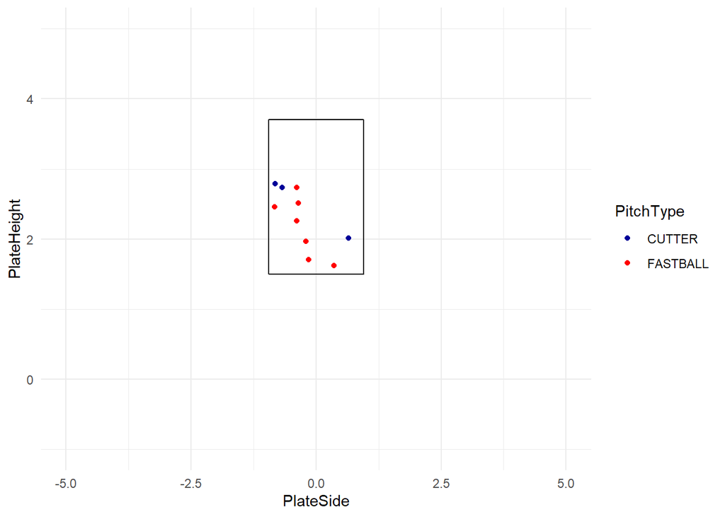

### Change in Whiff Probability Vs Left

| Change in Whiff Probabilty in Pitcher’s Counts Vs Left Pitch Type | Change in Whiff Probabilty in Pitcher’s Counts Vs Left Average Whiff Probability | Change in Whiff Probabilty in Pitcher’s Counts Vs Left Average Whiff Probability in Pitcher’s Count | Change in Whiff Probabilty in Pitcher’s Counts Vs Left Change in Whiff Probability due to Count |
| --- | --- | --- | --- |
| CHANGEUP | 0.1478895 | 0.1754781 | 0.0275886 |
| CURVEBALL | 0.0922867 | 0.1889118 | 0.0966251 |
| CUTTER | 0.1249060 | 0.1528584 | 0.0279525 |
| FASTBALL | 0.0691044 | 0.1041435 | 0.0350391 |

### Vs Right Total

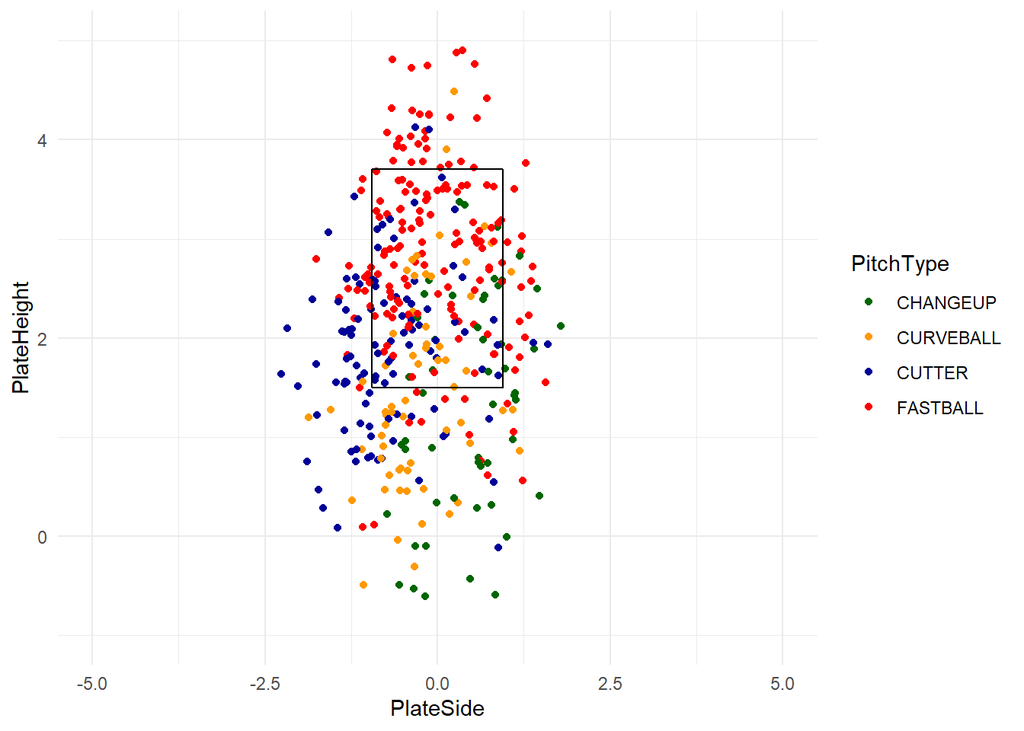

### Best Whiff Probabilities Vs Right

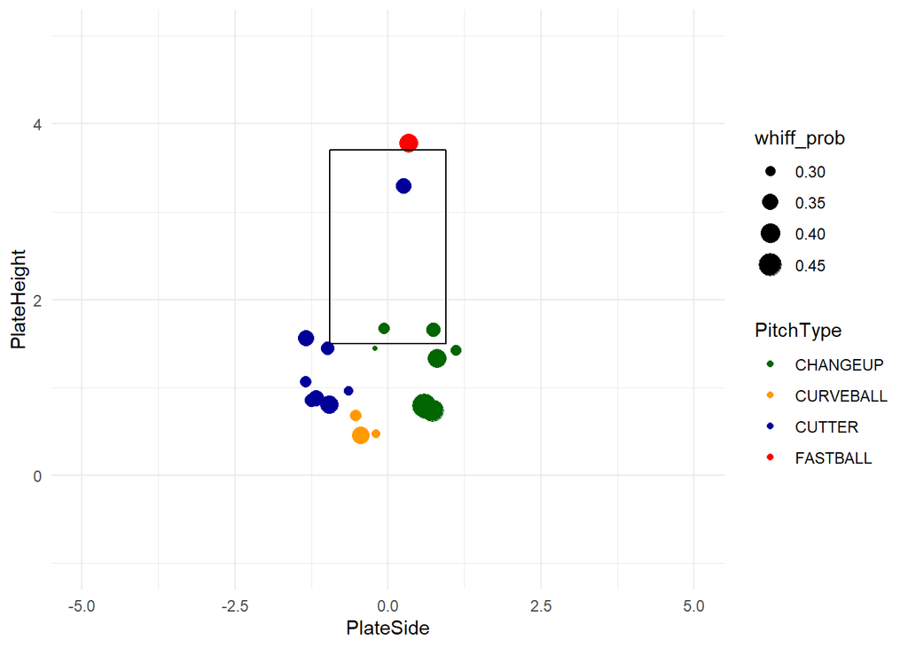

### Worst Whiff Probabilities Vs Right

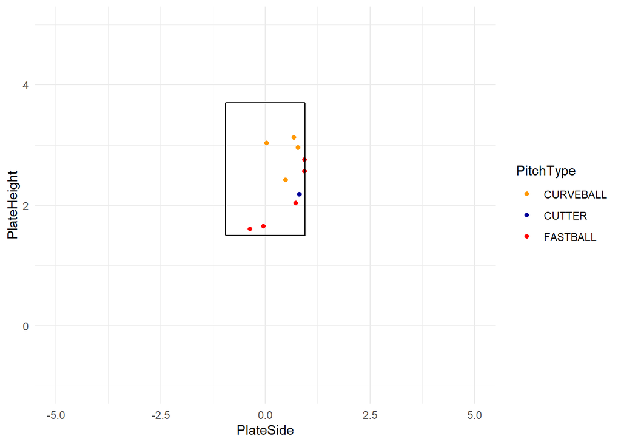

### Change in Whiff Probability Vs Right

| Change in Whiff Probabilty in Pitcher’s Counts Vs Right Pitch Type | Change in Whiff Probabilty in Pitcher’s Counts Vs Right Average Whiff Probability | Change in Whiff Probabilty in Pitcher’s Counts Vs Right Average Whiff Probability in Pitchers’s Count | Change in Whiff Probabilty in Pitcher’s Counts Vs Right Change in Whiff Probability due to Count |
| --- | --- | --- | --- |
| CHANGEUP | 0.1717387 | 0.1708378 | -0.0009009 |
| CURVEBALL | 0.1207239 | 0.1527158 | 0.0319920 |
| CUTTER | 0.1471326 | 0.1560260 | 0.0088934 |
| FASTBALL | 0.0970859 | 0.1221770 | 0.0250911 |

## Even Counts

### Vs Left Total

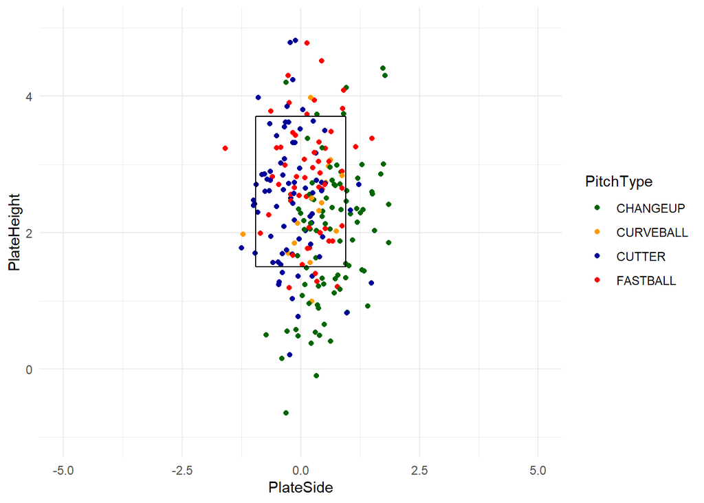

### Best Whiff Probabilities Vs Left

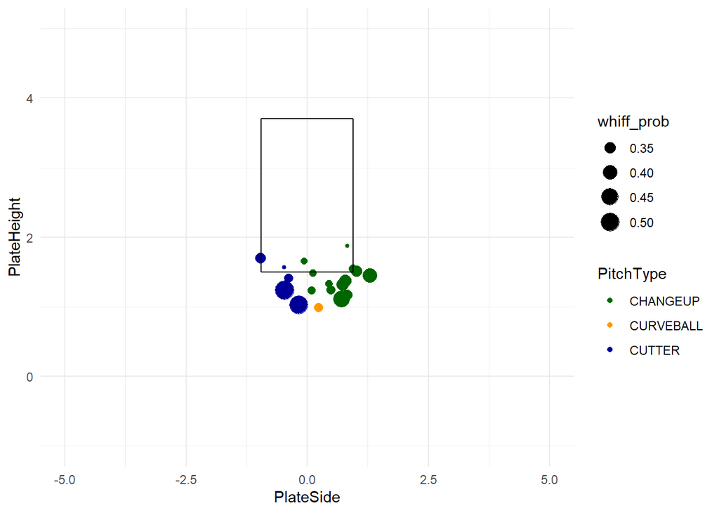

### Worst Whiff Probabilities Vs Left

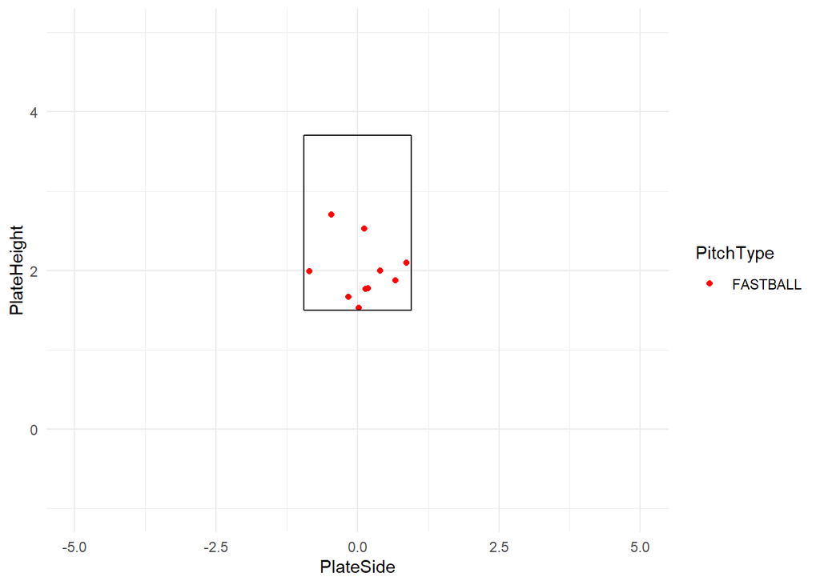

### Change in Whiff Probability Vs Left

| Change in Whiff Probabilty in Even Counts Vs Left Pitch Type | Change in Whiff Probabilty in Even Counts Vs Left Average Whiff Probability | Change in Whiff Probabilty in Even Counts Vs Left Average Whiff Probability in Even Count | Change in Whiff Probabilty in Even Counts Vs Left Change in Whiff Probability due to Count |
| --- | --- | --- | --- |
| CHANGEUP | 0.1478895 | 0.1635240 | 0.0156345 |
| CURVEBALL | 0.0922867 | 0.1092940 | 0.0170073 |
| CUTTER | 0.1249060 | 0.1444658 | 0.0195598 |
| FASTBALL | 0.0691044 | 0.0884059 | 0.0193015 |

### Vs Right Total

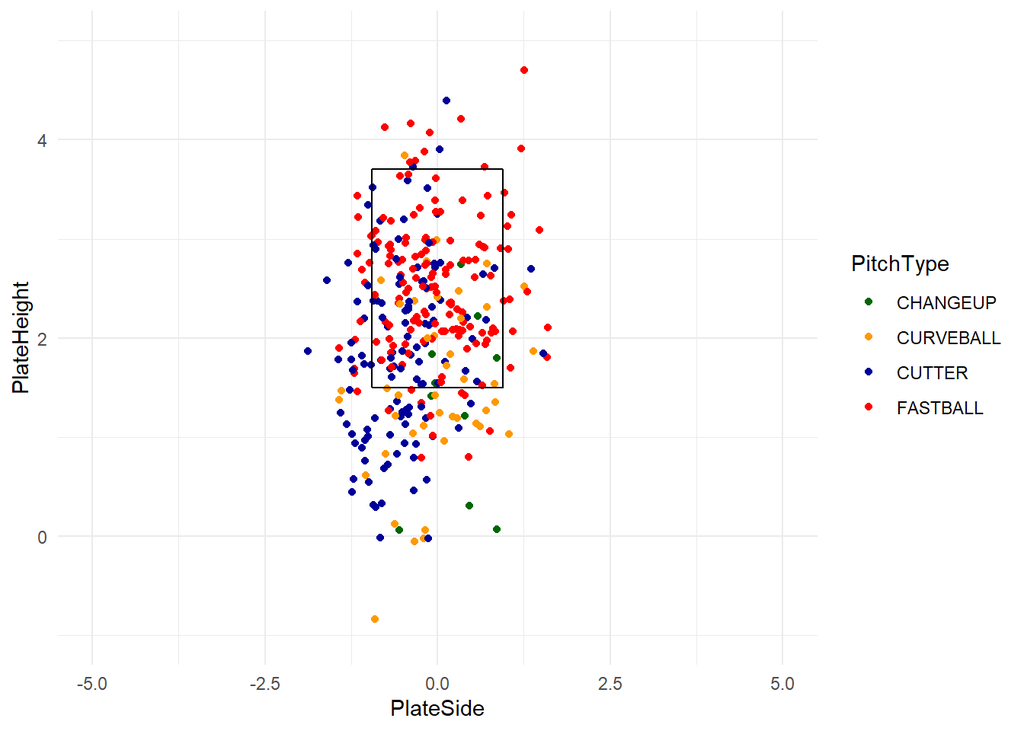

### Best Whiff Probabilities Vs Right

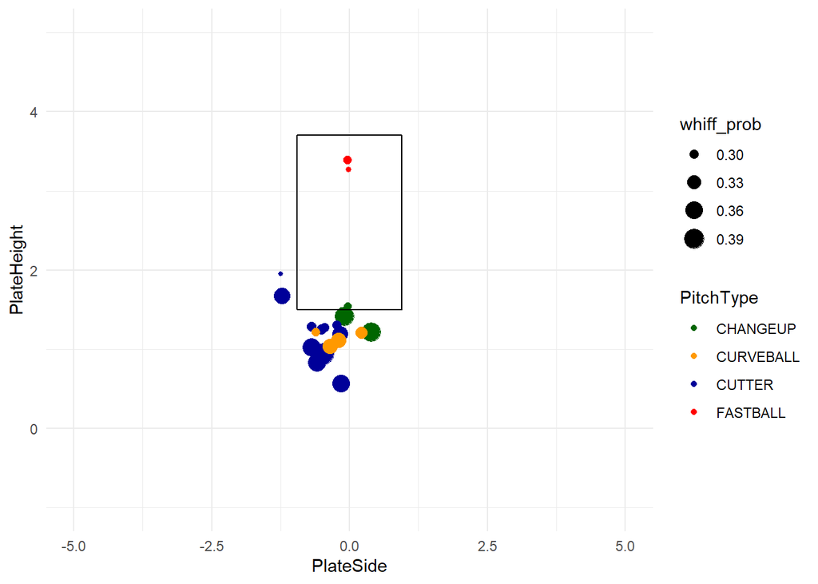

### Worst Whiff Probabilities Vs Right

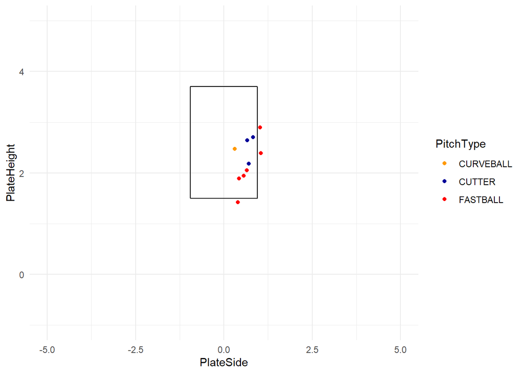

### Change in Whiff Probability Vs Right

| Change in Whiff Probabilty in Even Counts Vs Right Pitch Type | Change in Whiff Probabilty in Even Counts Vs Right Average Whiff Probability | Change in Whiff Probabilty in Even Counts Vs Right Average Whiff Probability in Even Count | Change in Whiff Probabilty in Even Counts Vs Right Change in Whiff Probability due to Count |
| --- | --- | --- | --- |
| CHANGEUP | 0.1717387 | 0.2170233 | 0.0452846 |
| CURVEBALL | 0.1207239 | 0.1464758 | 0.0257519 |
| CUTTER | 0.1471326 | 0.1645488 | 0.0174162 |
| FASTBALL | 0.0970859 | 0.1141468 | 0.0170609 |

## Early Counts

### Vs Left Total

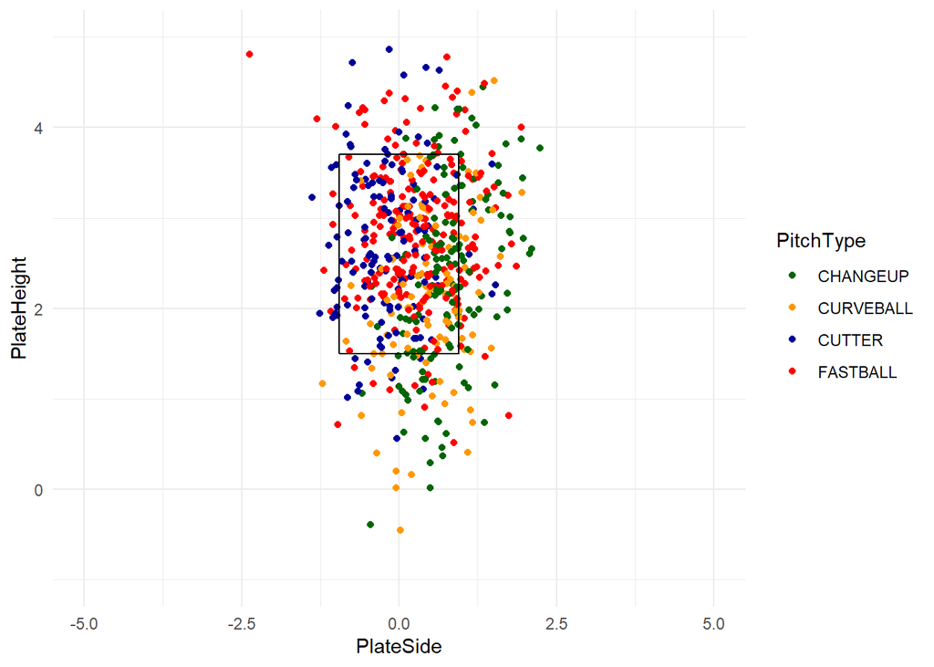

### Best Whiff Probabilities Vs Left

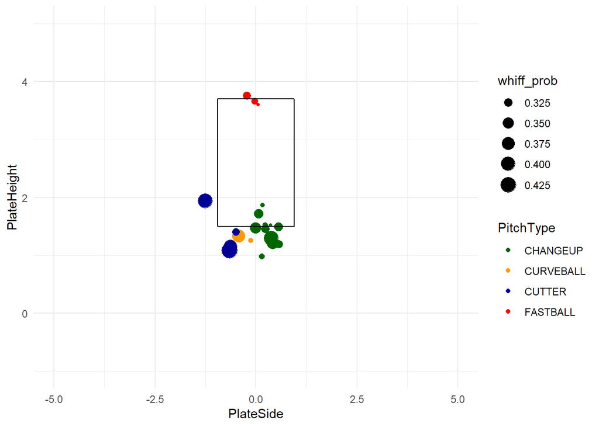

### Worst Whiff Probabilities Vs Left

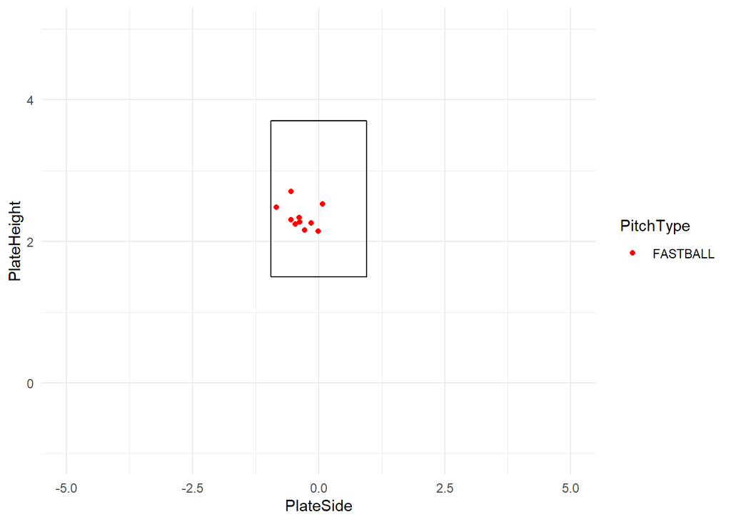

### Change in Whiff Probability Vs Left

| Change in Whiff Probabilty in Early Counts Vs Left Pitch Type | Change in Whiff Probabilty in Early Counts Vs Left Average Whiff Probability | Change in Whiff Probabilty in Early Counts Vs Left Average Whiff Probability in Early Counts | Change in Whiff Probabilty in Early Counts Vs Left Change in Whiff Probability due to Count |
| --- | --- | --- | --- |
| CHANGEUP | 0.1478895 | 0.1248495 | -0.0230401 |
| CURVEBALL | 0.0922867 | 0.0569761 | -0.0353106 |
| CUTTER | 0.1249060 | 0.1070655 | -0.0178405 |
| FASTBALL | 0.0691044 | 0.0549770 | -0.0141274 |

### Vs Right Total

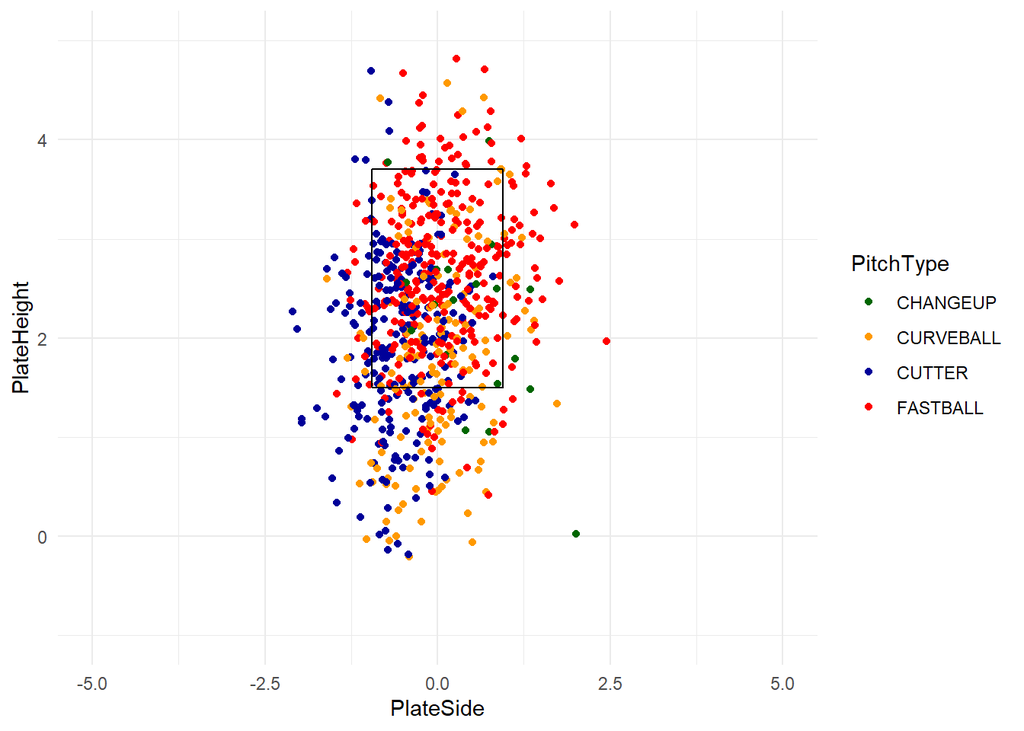

### Best Whiff Probabilities Vs Right

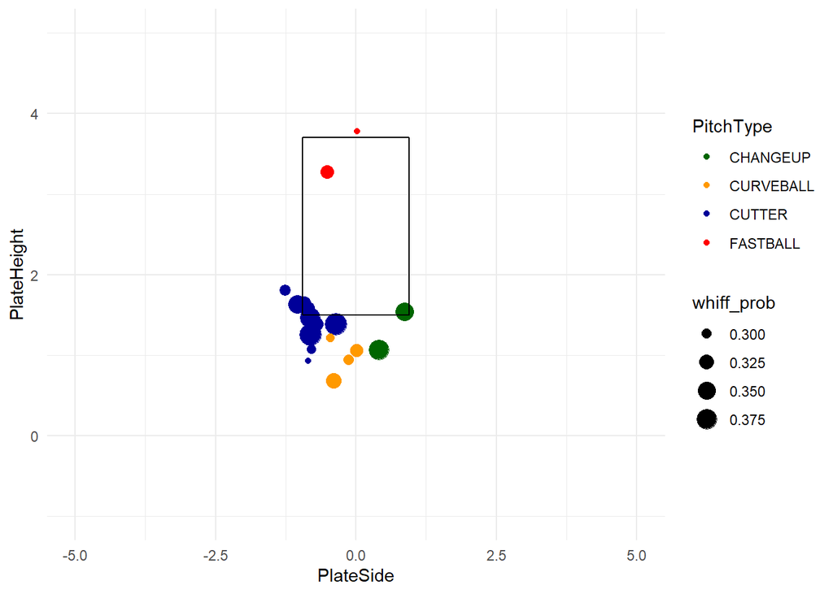

### Worst Whiff Probabilities Vs Right

[figure not shown]

### Change in Whiff Probability Vs Right

| Change in Whiff Probabilty in Early Counts Vs Right Pitch Type | Change in Whiff Probabilty in Early Counts Vs Right Average Whiff Probability | Change in Whiff Probabilty in Early Counts Vs Right Average Whiff Probability in Early Counts | Change in Whiff Probabilty in Early Counts Vs Right Change in Whiff Probability due to Count |
| --- | --- | --- | --- |
| CHANGEUP | 0.1717387 | 0.1585588 | -0.0131799 |
| CURVEBALL | 0.1207239 | 0.0996244 | -0.0210994 |
| CUTTER | 0.1471326 | 0.1365904 | -0.0105422 |
| FASTBALL | 0.0970859 | 0.0774537 | -0.0196322 |

## Takeaways from this section

- Vs Left: Fastballs should more come in even, early, or hitter’s counts. Cutters should more come in even or early counts. Changeups should come in all counts because they are best. Curveballs should come a lot more in pitcher’s counts and a little more in even counts.
- Vs Right: Fastballs should come more in hitter’s and pitcher’s counts. Cutters should come more in early and hitter’s counts. Changeups should come in all counts, but the most in even counts. Curveballs should come more in pitcher’s counts.

# Conclusions

- Changeup usage vs right increasing is the easiest way to see higher whiff probabilities.
  - It is his best pitch and should be used as such.
- Fastballs down in the zone are almost always the worst whiff probability pitches.
  - Pitcher X need to make sure Fastballs are at the top of the zone.
- Curveballs are much more effective when thrown below the zone and when thrown in pitcher’s counts especially vs lefities.
  - Thus they should be used more in those counts than they are in others.
  - Spins it well, so it could be a very effective pitch.
- Cut and Change are better when they have lower induced vertical break.
  - If Pitcher X can find a cue in bullpens to make this movement more consistent these two pitches will be even better.
- The best pitches are the best pitches in all counts, but usage based on how the pitch is effected in the count can help optimize whiff probability.
- Most of the best whiff probabilities are outside of the zone, so Pitcher X can’t be afraid to throw just out of the zone to get swing and miss.